# Domača naloga 5

Natasa Kejzar

5.3.2019

# Naloga 5

V novicah zasledimo, da delež dijakov (fantov), ki obiskujejo poklicne in strokovne srednješolske programe, narašča. V letu 2016/17 so zabeležili 73% dijakov na teh programih. Radi bi preverili, ali se ta trend nadaljuje. Na vzorcu 250 dijakov dobimo 183 tistih na poklicnih in strokovnih programih (PSP).

Ničelna domneva: $\pi_0 \leq 0.73$ je sestavljena.

Alternativna je prav tako sestavljena $\pi_A > 0.73$.

Prostor parametra $\Theta = [0,1]$, prostor $H_0: \Theta_0 = [0,0.73]$, prostor $H_A: \Theta_A = (0.73,1]$.

## Testna statistika

Osnovni podatki so Bernoullijeve spremenljivke ($X_i$), za testno statistiko lahko vzamemo delež, ali še lažje, kar vsoto Bernoullijevih spremenljivk, za katero vemo, da je porazdeljena po $Bin(n,\pi)$, kjer je $\pi$ parameter Bernoullijeve porazdelitve.

$T = \sum_{i=1}^n X_i \sim Bin(n,\pi)$

Za $\pi$ vzamemo najvišjo vrednost parametra pod $H_0$ ($\pi = 0.73$), saj pri tem ničelnem parametru verjetnost, da bomo zavrnili $H_0$ za malo verjetne (“čudne”) vrednosti testne statistike, najhitreje doseže $\alpha$. Gl. definicijo za stopnjo značilnosti s predavanj: $\alpha = \sup_{\theta \in \Theta_0} P(\mbox{zavrnemo }H_0)$.

Predpostavke:

- neodvisnost enot, iid: (1) če izberemo naključni vzorec, je neodvisnost smiselna; (2) manj smiselno pa je verjeti, da ima vsak mladostnik enako verjetnost, da bo želel in se vpisal na PSP.

## Meja zavrnitve, velikost testa

```r
pi=0.73
n=250
# meja zavrnitve
meja = qbinom(0.05,size=n,prob=pi,lower.tail=FALSE)
meja
```

```
## [1] 194
```

```r
pbinom(meja,size=n,prob=pi,lower.tail=FALSE) # meja ni tocno na 0.05, diskretna porazd.
```

```
## [1] 0.04153792
```

Zavračamo torej za vrednosti večje od 194 ($P(X > meja) < 0.05$).

Za katerokoli vrednost $\pi < 0.73$ bi dobili manjšo p-vrednost, torej bi hitreje zavrnili $H_0$, velja pa, da zavračamo $H_0$ le za primer, ko
$$\alpha = \sup_{\theta \in \Theta_0} P(\mbox{zavrnemo }H_0).$$
Velikost testa je načeloma enaka $\alpha$, vendar v tem primeru to ni popolnoma res, saj gre za diskretno spremenljivko, ki spreminja verjetnosti skokoma. V tem primeru je velikost testa enaka 0.0415379.

## Vrednost p in interpretacija

```r
# pvrednost
pbinom(183-1,size=n,prob=pi,lower.tail=FALSE) # P(X >= 183)
```

```
## [1] 0.5043671
```

Dobili smo statistično neznačilen rezultat, torej ne moremo trditi, da se je v populaciji dijakov delež tistih na PSP od š.l. 2016/17 povečal.

## Simulacije

```r
simuliraj <- function(ponovi,n,piVzorec,pi){
  pVrednosti = rep(NA,ponovi)
  for(i in 1:ponovi){
    vzorec = rbinom(1,size=n,prob=piVzorec)
    pVrednosti[i] = pbinom(vzorec-1,size=n,prob=pi,lower.tail=FALSE)
  }
  pVrednosti
}

# H_0 drzi
pVrednosti = simuliraj(1000,n,pi,pi)
table(pVrednosti < 0.05)
```

```
##
## FALSE  TRUE
##   944    56
```

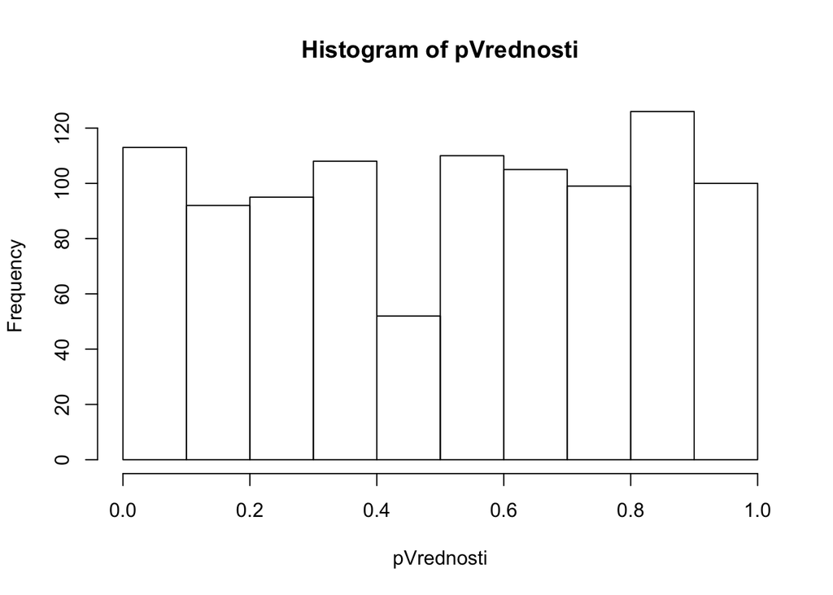

```r
hist(pVrednosti)
```

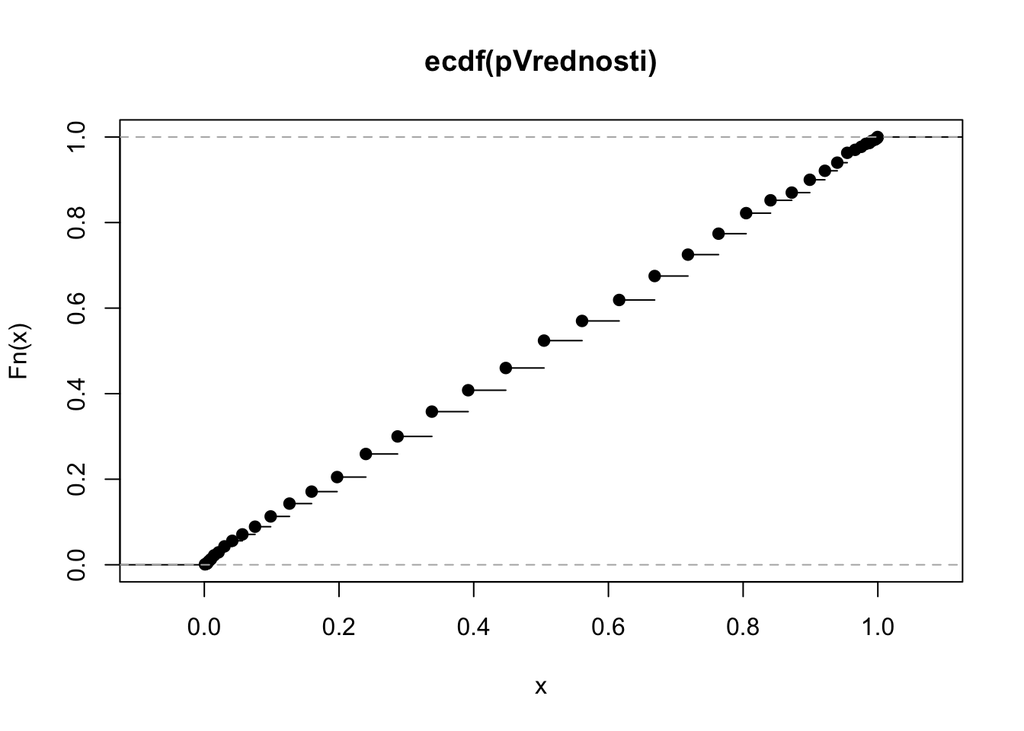

```r
plot(ecdf(pVrednosti))
```

Porazdelitev je približno enakomerna (torej se vse vrednosti p pojavljajo približno enako pogosto). Do skokov pride zaradi diskretnosti spremenljivke in *relativno* majhnega vzorca.

```r
# H_0 ne drzi
pVrednosti = simuliraj(1000,n,0.8,pi)
table(pVrednosti < 0.05)
```

```
##
## FALSE  TRUE
##   185   815
```

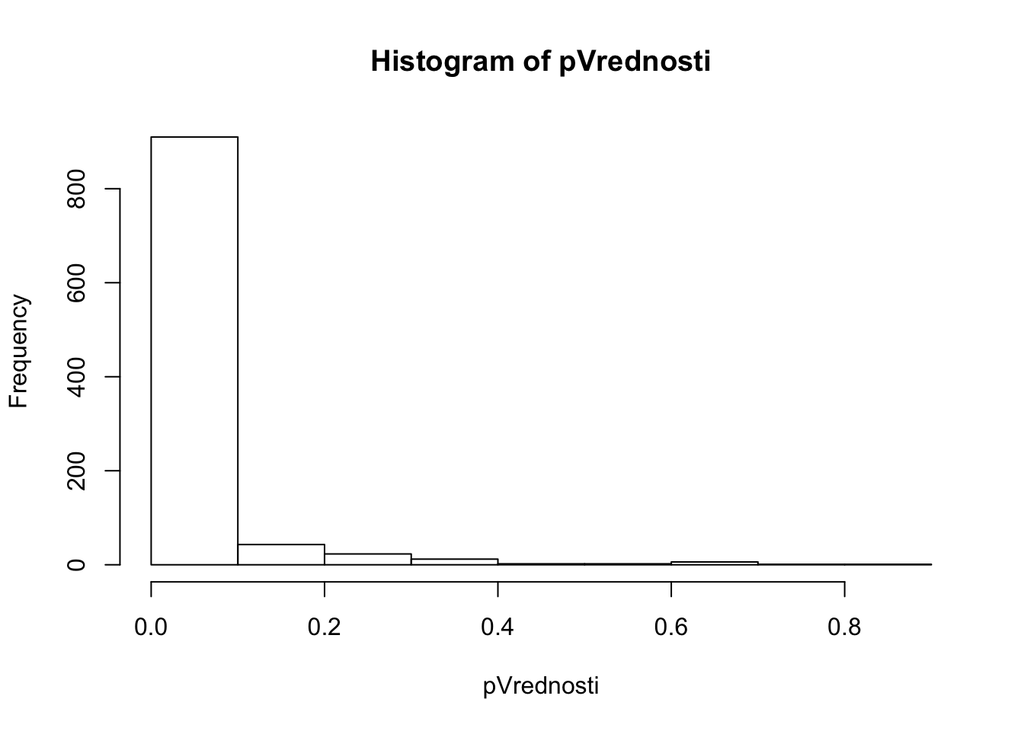

```r
hist(pVrednosti)
```

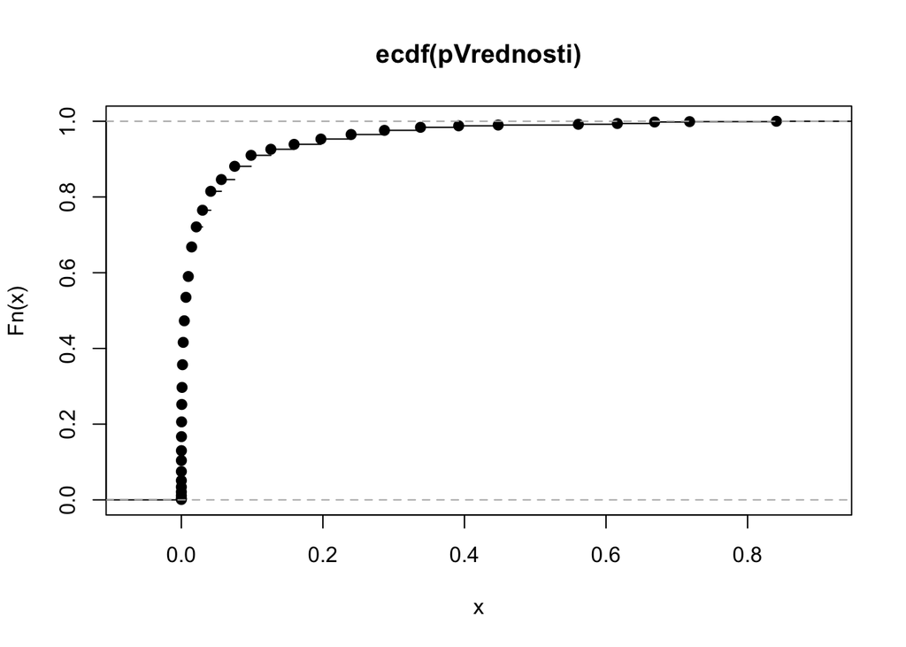

```r
plot(ecdf(pVrednosti))
```

V tem primeru vidimo, da je veliko več vrednosti p majhnih, kar pomeni, da test bolj pogosto zavrača ničelno domnevo.

### Majhen $n=20$

```r
# H_0 drzi
pVrednosti = simuliraj(1000,20,pi,pi)
table(pVrednosti < 0.05)
```

```
##
## FALSE  TRUE
##   976    24
```

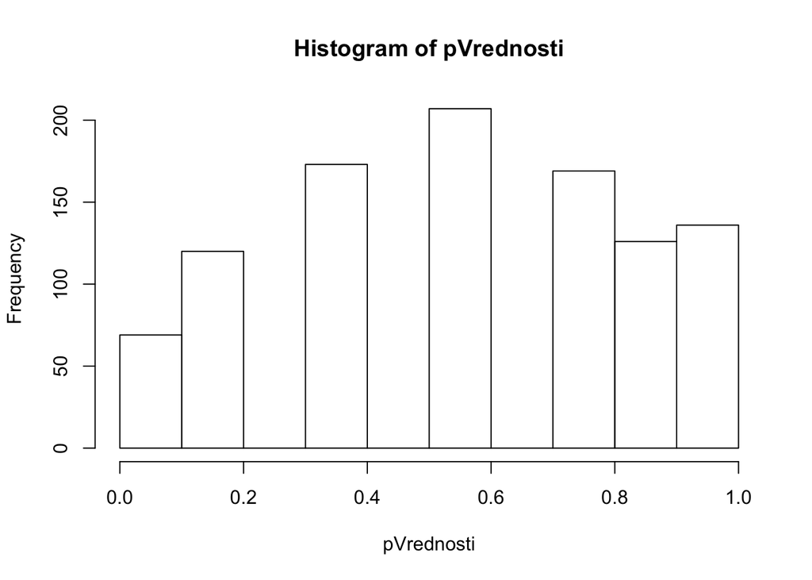

```r
hist(pVrednosti)
```

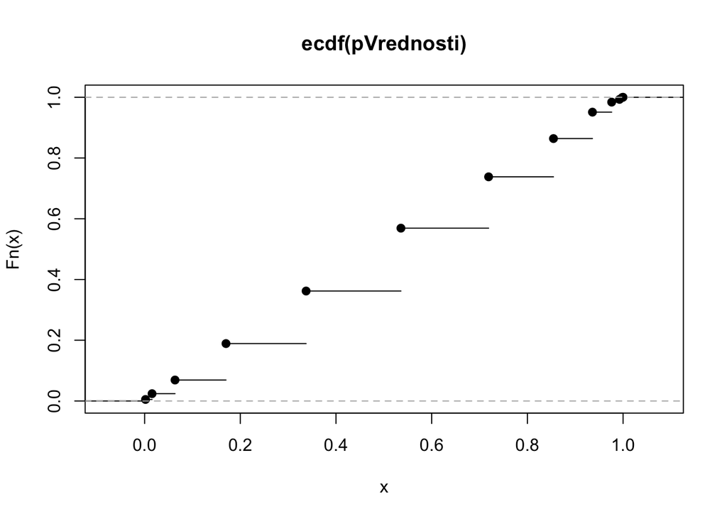

```r
plot(ecdf(pVrednosti))
```

Porazdelitev ima velike skoke zaradi majhnega vzorca in diskretnih podatkov. Iz histograma niti ne vidimo več enakomernosti.

```r
# H_0 ne drzi
pVrednosti = simuliraj(1000,20,0.8,pi)
table(pVrednosti < 0.05)
```

```
##
## FALSE  TRUE
##   934    66
```

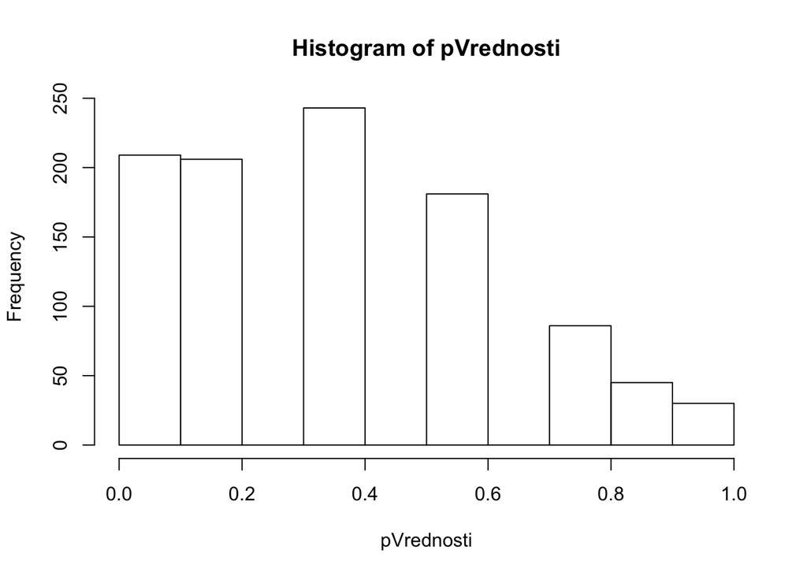

```r
hist(pVrednosti)
```

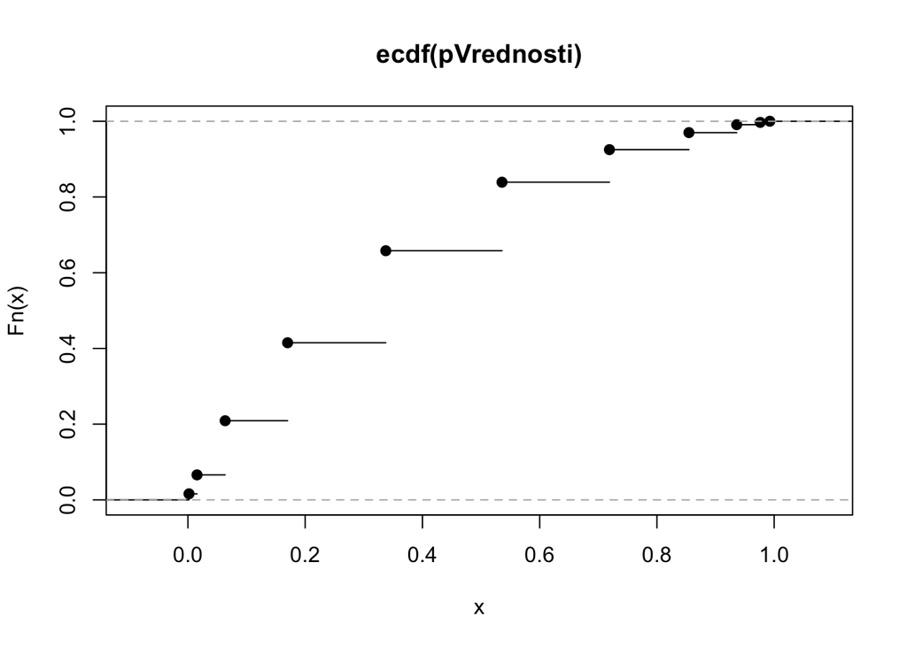

```r
plot(ecdf(pVrednosti))
```

Tudi v tem primeru se ne vidi kake posebne oblike porazdelitve. To vidimo zaradi majhnega vzorca in hkrati majhne razlike med ničelno in alternativno domnevo. Test ima precej manjšo moč.

## Moč testa

```r
# moc testa
pbinom(meja,size=250,prob=0.8,lower.tail=FALSE)
```

```
## [1] 0.8088391
```

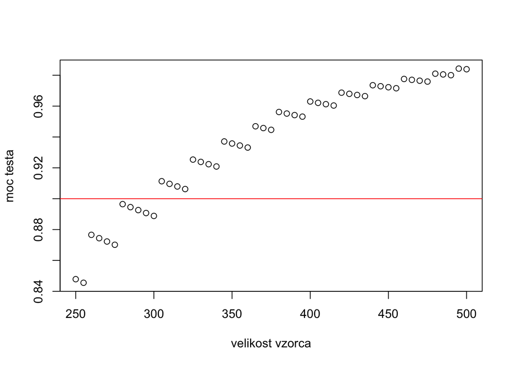

```r
# moc vsaj 0.9
velikostn = seq(250,500,5)
moci = NULL
for(n in velikostn){
  meja = qbinom(0.05,size=n,prob=pi,lower.tail=FALSE)
  moci = c(moci,pbinom(meja-1,size=n,prob=0.8,lower.tail=FALSE))
}
plot(velikostn,moci,xlab="velikost vzorca",ylab="moc testa")
abline(h=0.9,col="red")
```

Da bi lahko z 90% verjetnostjo zavrnili ničelno domnevo, če je pravi delež PSPjevcev 0.8, potem moramo v vzorec nabrati nekaj več kot 300 oseb.